# Development of a methodolygy to quantify compounds with Seal AA3

Antoine Batigny & Guyliann Engels

14 & 15 december 2017

# Aim

- We use Stareso sea water to prepare calibration line because we think that the SSW is contaminated

# Introduction

we use the Seal AA3 to compare several water’s solutions (fresh water and sea water) with the addition of nitrogen and phosphorus compounds.

We analyse :

- The Stareso sea water.

This water is aged with several cycles (light/ dark cycles). The organisms in water will use all available nutrients. this sea water is logically clean.

- The ultrapure water ( type 1, Millipore Corporation)

This water is described as ultrapure water (Type1). attention, the salinity is different between sample. a fresh water and sea water are not comparable.

- The Synthetic sea Water (SSW)
- The Stareso sea water with addition of 0.05, 0.1, 0.2, 1, 2, 5 and 10 $\mu mol/L$ for $PO_4$, $NO_3$ and $NH_4$ (method A). The Stareso sea water with addition of 0.05, 1, 30 $\mu mol/L$ for $Ptot$ and $Ntot$ (method B). The Stareso sea water with addition of 0.05, 1, 10 $\mu mol/L$ for $NO_2$. (method B)

# M&M

- Calibration lines are realised with Stareso sea water
- Solvant for seal AA3 are realsied with Stareso sea water
- each sample is measured 10 times (except calibration line)

# Results

```r
library(tidyverse)#version 1.1.1
library(ggpubr)#version0.1.6
library(gridExtra)#version 2.2.1
library(knitr)#version 1.17
data <- read.table(file = "../data/171215A.txt", sep = ";", header = TRUE) # import dataset
# check the method, line 8 , two possibility : method A (PO4, NO3, NH4) or method B (Ptot, Ntot, NO2)
# skip first line
meth_a <- data[ -c(1:13), ]
remove(data)
# rename variable for more simplicity
meth_a %>%rename(echant = ANAL, type  = X.1, date_analyse = X.5,
                PO4_theo = X.6, PO4_conc = X.7, PO4_val = X.8,
                NO3_theo = X.9, NO3_conc = X.10, NO3_val = X.11,
                NH4_theo = X.12, NH4_conc = X.13, NH4_val = X.14)%>%
  select(c(1,4,8:17))-> meth_a
# special attention for the type of variables and change if necessary
meth_a %>% mutate(echant = as.character(echant),
                  type = as.character(type),
                  PO4_theo = as.numeric(as.character(PO4_theo)),
                  PO4_conc = as.numeric(as.character(PO4_conc)),
                  PO4_val = as.numeric(as.character(PO4_val)),
                  NO3_theo = as.numeric(as.character(NO3_theo)),
                  NO3_conc = as.numeric(as.character(NO3_conc)),
                  NO3_val = as.numeric(as.character(NO3_val)),
                  NH4_theo = as.numeric(as.character(NH4_theo)),
                  NH4_conc = as.numeric(as.character(NH4_conc)),
                  NH4_val = as.numeric(as.character(NH4_val))) -> meth_a
meth_a$date_analyse <- as.POSIXlt(meth_a$date_analyse, format = "%d/%m/%Y %H:%M:%S")
meth_a$date_analyse <- as.POSIXct(meth_a$date_analyse)
# Import second dataset and check method
meth<- read.table(file = "../data/171214A.txt", sep = ";", header = TRUE)
# check the method, line 8 , two possibility : method A (PO4, NO3, NH4) or method B (Ptot, Ntot, NO2)
## If METHOD B
# skip first line
meth_b <- meth[ -c(1:13), ]
remove(meth)
# rename variable for more simplicity
meth_b %>%rename(echant = ANAL, type  = X.1, date_analyse = X.5,
                Ptot_theo = X.6, Ptot_conc = X.7, Ptot_val = X.8,
                Ntot_theo = X.9, Ntot_conc = X.10, Ntot_val = X.11,
                NO2_theo = X.12, NO2_conc = X.13, NO2_val = X.14)%>%
  select(c(1,4,8:17))-> meth_b
# special attention for the type of variables and change if necessary
meth_b %>% mutate(echant = as.character(echant),
                  type = as.character(type),
                  Ptot_theo = as.numeric(as.character(Ptot_theo)),
                  Ptot_conc = as.numeric(as.character(Ptot_conc)),
                  Ptot_val = as.numeric(as.character(Ptot_val)),
                  Ntot_theo = as.numeric(as.character(Ntot_theo)),
                  Ntot_conc = as.numeric(as.character(Ntot_conc)),
                  Ntot_val = as.numeric(as.character(Ntot_val)),
                  NO2_theo = as.numeric(as.character(NO2_theo)),
                  NO2_conc = as.numeric(as.character(NO2_conc)),
                  NO2_val = as.numeric(as.character(NO2_val))) -> meth_b
meth_b$date_analyse <- as.POSIXlt(meth_b$date_analyse, format = "%d/%m/%Y %H:%M:%S")
meth_b$date_analyse <- as.POSIXct(meth_b$date_analyse)
```

## Calibration curves

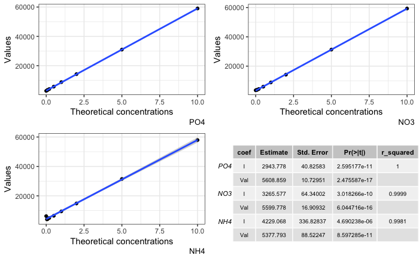

```r
# select CALB to check a good calibration line
meth_a%>%filter(type == "CALB") -> calb_a
# If ok next step, otherwise compute a new variable with best calibration line between theorical values and obtained values
#PO4
PO4_graph <- ggplot(data = calb_a, mapping = aes(x = PO4_theo, y = PO4_val))+
  geom_point()+
  geom_smooth(method = "lm") +
  labs( x = "Theoretical concentrations", y = "Values", caption = "PO4") +
  theme(plot.caption = element_text(hjust = 0.5)) +
  theme_bw()
# simply graph to visualize the calibration line for PO4
# Compute linear regression and extract r^2^ for PO4
PO4_reg <-lm(PO4_val ~ PO4_theo, data =  calb_a)
summary((PO4_reg))$coefficients -> PO4_tab
PO4_tab <- as.data.frame(PO4_tab)
round(summary((PO4_reg))$r.squared, 4) -> r_squared
PO4_tab$r_squared <- c(r_squared, " ")
# Same procedure for all elements
#NO3
NO3_graph <- ggplot(data = calb_a, mapping = aes(x = NO3_theo, y = NO3_val))+
  geom_point()+
  geom_smooth(method = "lm")+
  labs( x = "Theoretical concentrations", y = "Values", caption = "NO3")+
  theme(plot.caption = element_text(hjust = 0.5))+
  theme_bw()
NO3_reg <-lm(NO3_val ~ NO3_theo, data =  calb_a)
summary((NO3_reg))$coefficients -> NO3_tab
NO3_tab <- as.data.frame(NO3_tab)
round(summary((NO3_reg))$r.squared, 4) -> r_squared
NO3_tab$r_squared <- c(r_squared, " ")
#NH4
NH4_graph <- ggplot(data = calb_a, mapping = aes(x = NH4_theo, y = NH4_val))+
  geom_point()+
  geom_smooth(method = "lm") +
  labs( x = "Theoretical concentrations", y = "Values", caption = "NH4")+
  theme(plot.caption = element_text(hjust = 0.5))+
  theme_bw()
NH4_reg <-lm(NH4_val ~ NH4_theo, data =  calb_a)
summary((NH4_reg))$coefficients -> NH4_tab
NH4_tab <- as.data.frame(NH4_tab)
round(summary((NH4_reg))$r.squared, 4) -> r_squared
NH4_tab$r_squared <- c(r_squared, " ")
calb_tab <- bind_rows( PO4_tab, NO3_tab, NH4_tab)
calb_tab_a <- data_frame(coef= c( "I", "Val",  "I", "Val",  "I", "Val"))
calb_tab <- bind_cols(calb_tab_a, calb_tab)
## Template for tab
mytheme <- gridExtra::ttheme_default(
    core = list(fg_params=list(cex = 0.6)),
    colhead = list(fg_params=list(cex = 0.7)),
    rowhead = list(fg_params=list(cex = 0.7)))
## Create tab with lm's coefficients
tab <- tableGrob(calb_tab[ , - c(4)], theme = mytheme, rows = c("PO4", " ", "NO3", " ", "NH4", ""))
#multiplot
ggarrange(PO4_graph, NO3_graph, NH4_graph, tab)
```

```r
remove(calb_tab, calb_tab_a, mytheme, NH4_graph, NH4_reg, NH4_tab, NO3_graph, NO3_reg, NO3_tab, PO4_graph, PO4_reg, PO4_tab, tab)
```

The r<sup>2</sup> of calibration line are close to 1.

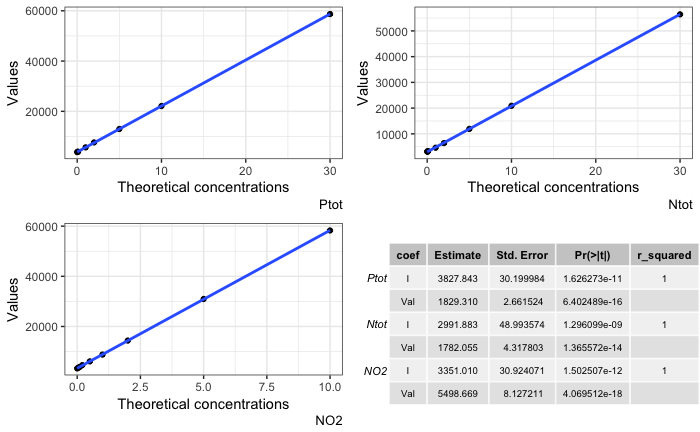

```r
# select CALB to check a good calibration line
meth_b%>%filter(type == "CALB") -> calb_b
#Ptot
Ptot_graph <- ggplot(data = calb_b[c(1:8), ], mapping = aes(x = Ptot_theo, y = Ptot_val))+
  geom_point()+
  geom_smooth(method = "lm") + labs( x = "Theoretical concentrations", y = "Values", caption = "Ptot")+
  theme(plot.caption = element_text(hjust = 0.5))+
  theme_bw()
Ptot_reg <-lm(Ptot_val ~ Ptot_theo, data =  calb_b[c(1:8), ])
summary((Ptot_reg))$coefficients -> Ptot_tab
Ptot_tab <- as.data.frame(Ptot_tab)
round(summary((Ptot_reg))$r.squared, 4) -> r_squared
Ptot_tab$r_squared <- c(r_squared, " ")
#Ntot
Ntot_graph <- ggplot(data = calb_b[c(1:8), ], mapping = aes(x = Ntot_theo, y = Ntot_val))+
  geom_point()+
  geom_smooth(method = "lm")+
  labs( x = "Theoretical concentrations", y = "Values", caption = "Ntot")+
  theme(plot.caption = element_text(hjust = 0.5))+
  theme_bw()
Ntot_reg <-lm(Ntot_val ~ Ntot_theo, data =  calb_b[c(1:8), ])
summary((Ntot_reg))$coefficients -> Ntot_tab
Ntot_tab <- as.data.frame(Ntot_tab)
round(summary((Ntot_reg))$r.squared, 4) -> r_squared
Ntot_tab$r_squared <- c(r_squared, " ")
#NO2
NO2_graph <- ggplot(data = calb_b[c(9:17), ], mapping = aes(x = NO2_theo, y = NO2_val))+
  geom_point()+
  geom_smooth(method = "lm") +
  labs( x = "Theoretical concentrations", y = "Values", caption = "NO2")+
  theme(plot.caption = element_text(hjust = 0.5))+
  theme_bw()
NO2_reg <-lm(NO2_val ~ NO2_theo, data =  calb_b[c(9:17), ])
summary((NO2_reg))$coefficients -> NO2_tab
NO2_tab <- as.data.frame(NO2_tab)
round(summary((NO2_reg))$r.squared, 4) -> r_squared
NO2_tab$r_squared <- c(r_squared, " ")
calb_tab <- bind_rows( Ptot_tab, Ntot_tab, NO2_tab)
calb_tab_b <- data_frame(coef= c( "I", "Val",  "I", "Val",  "I", "Val"))
calb_tab <- bind_cols(calb_tab_b, calb_tab)
## Template for tab
mytheme <- gridExtra::ttheme_default(
    core = list(fg_params=list(cex = 0.6)),
    colhead = list(fg_params=list(cex = 0.7)),
    rowhead = list(fg_params=list(cex = 0.7)))
## Create tab with lm's coefficients
tab <- tableGrob(calb_tab[ , - c(4)], theme = mytheme, rows = c("Ptot", " ", "Ntot", " ", "NO2", ""))
#multiplot
ggarrange(Ptot_graph, Ntot_graph, NO2_graph, tab)
```

```r
remove(calb_tab, calb_tab_b, mytheme, NO2_graph, NO2_reg, NO2_tab, Ntot_graph, Ntot_reg, Ntot_tab, Ptot_graph, Ptot_reg, Ptot_tab, tab)
```

The r<sup>2</sup> of calibration line round to 1.

## Samples

```r
#meth A
meth_a%>%filter(type == "SAMP") -> samp_a # select only samp (so no calibration or drift points)
samp_a %>%
  filter(echant != "Milliq") -> samp_a
samp_a$echant <- factor(x = samp_a$echant,ordered = TRUE,levels = c("H2O Stareso", "SSW", "cal0.05", "cal0.1", "cal0.2", "cal1", "cal2", "cal5", "Cal10")) #arrange the echant by concentrations
#save data only for a short presentation lab meeting
write_rds(x = samp_a, path = "../Cache/conta_metha.rds")
#meth B
meth_b%>%filter(type == "SAMP") -> samp_b
## Recodage de samp_b$echant
samp_b$echant <- as.character(samp_b$echant)
samp_b$echant[samp_b$echant == "Milliq_____________"] <- "Milliq"
samp_b$echant[samp_b$echant == "ssw"] <- "SSW"
samp_b %>%
  filter(echant != "Milliq") -> samp_b
samp_b$echant <- factor(x = samp_b$echant, ordered = TRUE, levels = c("H2O Stareso", "Milliq", "SSW","cal0.05 N+P", "cal1 N+P", "cal30 N+P" ,"cal0.05 NO2", "cal1 NO2", "cal10 NO2" )) #arrange the echant by concentrations
```

### PO4

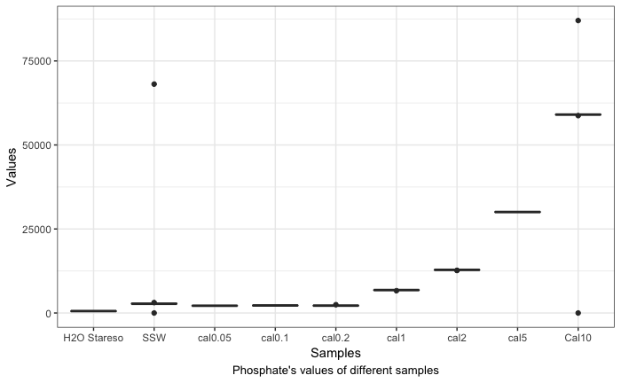

```r
ggplot(data = samp_a, mapping = aes(x = echant,y = PO4_val))+
  geom_boxplot() +
  labs( x = "Samples", y = "Values", caption = "Phosphate's values of different samples")+
  theme_bw() +
  theme(plot.caption = element_text(hjust = 0.5))
```

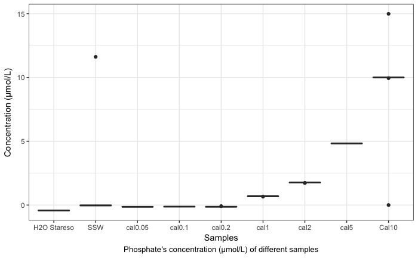

```r
ggplot(data = samp_a, mapping = aes(x = echant,y = PO4_conc))+
  geom_boxplot()+
  labs( x = "Samples", y = "Concentration (µmol/L)", caption = "Phosphate's concentration (µmol/L) of different samples")+
  theme_bw() +
  theme(plot.caption = element_text(hjust = 0.5))
```

The boxplots show several extreme points. We remove theses points.

```r
red <- samp_a[ -c(4, 19:20) , ]
red %>%
  group_by(echant)%>%
  summarise(mean = round(mean(PO4_conc), digits = 4),
            sd = round(sd(PO4_conc), digits = 4),cv = round(x = ((sd/mean)*100), digits = 4) ,
            number = length(PO4_conc)) -> red
kable(x = red , format = "pandoc", caption = "Mean, standard deviation (sd) and variation coefficient (cv) of phosphate's concentrations of different samples.")
```

Mean, standard deviation (sd) and variation coefficient (cv) of phosphate's concentrations of different samples.

| echant | mean | sd | cv | number |
| --- | --- | --- | --- | --- |
| H2O Stareso | -0.4251 | 0.0152 | -3.5756 | 10 |
| SSW | -0.0229 | 0.0248 | -108.2969 | 9 |
| cal0.05 | -0.1390 | 0.0071 | -5.1079 | 10 |
| cal0.1 | -0.1258 | 0.0137 | -10.8903 | 10 |
| cal0.2 | -0.1311 | 0.0197 | -15.0267 | 10 |
| cal1 | 0.6884 | 0.0145 | 2.1063 | 10 |
| cal2 | 1.7588 | 0.0134 | 0.7619 | 10 |
| cal5 | 4.8346 | 0.0176 | 0.3640 | 10 |
| Cal10 | 9.9955 | 0.0211 | 0.2111 | 8 |

In the calibration line, the values of Stareso sea water is of about 2800 ($0 \mu mol/L$) whereas the values of Stareso sea water in sample is of about 600 ($-0.42\mu mol/L$).

### NO3

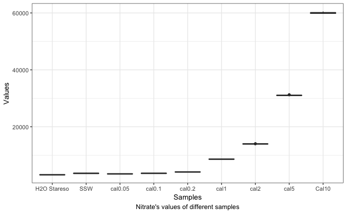

```r
ggplot(data = samp_a, mapping = aes(x = echant,y = NO3_val))+
  geom_boxplot() +
  labs( x = "Samples", y = "Values", caption = "Nitrate's values of different samples")+
  theme_bw() +
  theme(plot.caption = element_text(hjust = 0.5))
```

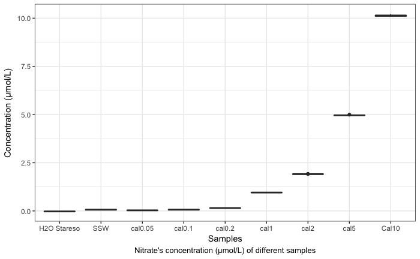

```r
ggplot(data = samp_a, mapping = aes(x = echant,y = NO3_conc))+
  geom_boxplot() +
  labs( x = "Samples", y = "Concentration (µmol/L)", caption = "Nitrate's concentration (µmol/L) of different samples")+
  theme_bw() +
  theme(plot.caption = element_text(hjust = 0.5))
```

```r
samp_a %>%
  group_by(echant)%>%
  summarise(mean = round(mean(NO3_conc), digits = 4),
            sd = round(sd(NO3_conc), digits = 4),cv = round(x = ((sd/mean)*100), digits = 4) ,
            number = length(NO3_conc)) -> a
kable(a, format = "pandoc", caption = "Mean, standard deviation (sd) and variation coefficient (cv) of nitrate's concentrations of different samples.")
```

Mean, standard deviation (sd) and variation coefficient (cv) of nitrate's concentrations of different samples.

| echant | mean | sd | cv | number |
| --- | --- | --- | --- | --- |
| H2O Stareso | -0.0255 | 0.0054 | -21.1765 | 10 |
| SSW | 0.0681 | 0.0186 | 27.3128 | 10 |
| cal0.05 | 0.0323 | 0.0099 | 30.6502 | 10 |
| cal0.1 | 0.0653 | 0.0118 | 18.0704 | 10 |
| cal0.2 | 0.1515 | 0.0076 | 5.0165 | 10 |
| cal1 | 0.9581 | 0.0105 | 1.0959 | 10 |
| cal2 | 1.9118 | 0.0046 | 0.2406 | 10 |
| cal5 | 4.9634 | 0.0122 | 0.2458 | 10 |
| Cal10 | 10.1333 | 0.0427 | 0.4214 | 10 |

### NH4

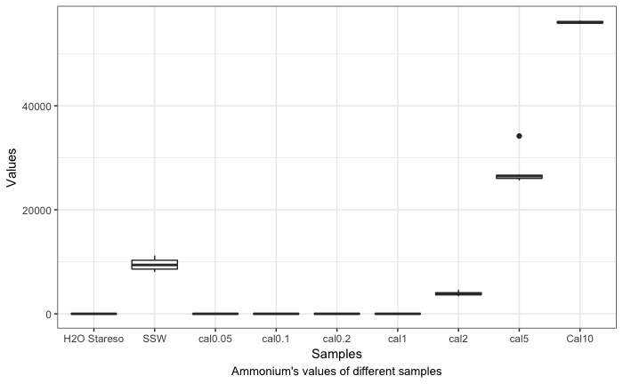

```r
ggplot(data = samp_a, mapping = aes(x = echant,y = NH4_val))+
  geom_boxplot() +
  labs( x = "Samples", y = "Values", caption = "Ammonium's values of different samples")+
  theme_bw() +
  theme(plot.caption = element_text(hjust = 0.5))
```

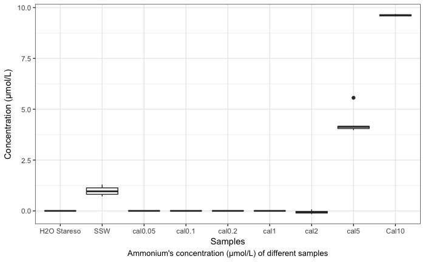

```r
ggplot(data = samp_a, mapping = aes(x = echant,y = NH4_conc))+
  geom_boxplot() +
  labs( x = "Samples", y = "Concentration (µmol/L)", caption = "Ammonium's concentration (µmol/L) of different samples")+
  theme_bw() +
  theme(plot.caption = element_text(hjust = 0.5))
```

Several values are zero values except SSW, 2 , 5 and 10 $\mu mol/L$.

### Ptot

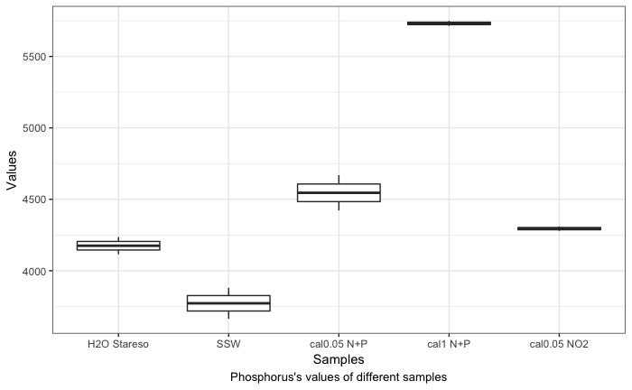

```r
ggplot(data = filter(samp_b, echant == c("H2O Stareso", "SSW","cal0.05 N+P", "cal1 N+P","cal0.05 NO2")), mapping = aes(x = echant,y = Ptot_val))+
  geom_boxplot() +
  labs( x = "Samples", y = "Values", caption = "Phosphorus's values of different samples")+
  theme_bw() +
  theme(plot.caption = element_text(hjust = 0.5))
```

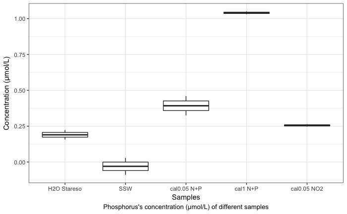

```r
ggplot(data = filter(samp_b, echant == c("H2O Stareso", "SSW","cal0.05 N+P", "cal1 N+P", "cal0.05 NO2")), mapping = aes(x = echant,y = Ptot_conc))+
  geom_boxplot() +
  labs( x = "Samples", y = "Concentration (µmol/L)", caption = "Phosphorus's concentration (µmol/L) of different samples")+
  theme_bw() +
  theme(plot.caption = element_text(hjust = 0.5))
```

```r
red <- samp_b[ -c(6, 10) , ]
red %>%
  group_by(echant)%>%
  summarise(mean = round(mean(Ptot_conc), digits = 4),
            sd = round(sd(Ptot_conc), digits = 4),cv = round(x = ((sd/mean)*100), digits = 4) ,
            number = length(Ptot_conc)) -> a
kable(a, format = "pandoc", caption = "Mean, standard deviation (sd) and variation coefficient (cv) of phosphorus' concentrations of different samples.")
```

Mean, standard deviation (sd) and variation coefficient (cv) of phosphorus' concentrations of different samples.

| echant | mean | sd | cv | number |
| --- | --- | --- | --- | --- |
| H2O Stareso | 0.1661 | 0.0317 | 19.0849 | 10 |
| SSW | -0.1134 | 0.0664 | -58.5538 | 8 |
| cal0.05 N+P | 0.3161 | 0.0554 | 17.5261 | 10 |
| cal1 N+P | 1.0868 | 0.0913 | 8.4008 | 10 |
| cal30 N+P | 30.1664 | 0.0707 | 0.2344 | 10 |
| cal0.05 NO2 | 0.4432 | 0.5191 | 117.1255 | 10 |
| cal1 NO2 | 0.1347 | 0.0259 | 19.2279 | 10 |
| cal10 NO2 | 0.5156 | 0.6342 | 123.0023 | 10 |

### Ntot

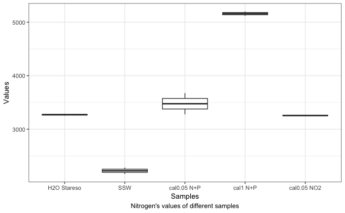

```r
ggplot(data = filter(samp_b, echant == c("H2O Stareso",  "SSW","cal0.05 N+P", "cal1 N+P","cal0.05 NO2")), mapping = aes(x = echant,y = Ntot_val))+
  geom_boxplot() +
  labs( x = "Samples", y = "Values", caption = "Nitrogen's values of different samples")+
  theme_bw() +
  theme(plot.caption = element_text(hjust = 0.5))
```

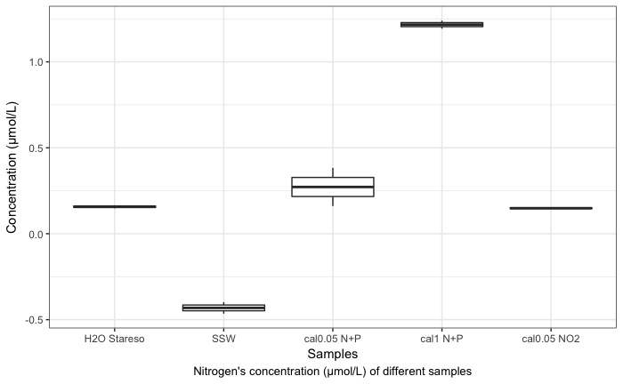

```r
ggplot(data = filter(samp_b, echant == c("H2O Stareso",  "SSW","cal0.05 N+P", "cal1 N+P", "cal0.05 NO2")), mapping = aes(x = echant,y = Ntot_conc))+
  geom_boxplot() +
  labs( x = "Samples", y = "Concentration (µmol/L)", caption = "Nitrogen's concentration (µmol/L) of different samples")+
  theme_bw() +
  theme(plot.caption = element_text(hjust = 0.5))
```

```r
samp_b %>%
  group_by(echant)%>%
  summarise(mean = round(mean(Ntot_conc), digits = 4),
            sd = round(sd(Ntot_conc), digits = 4),cv = round(x = ((sd/mean)*100), digits = 4) ,
            number = length(Ntot_conc)) -> a
kable(a, format = "pandoc", caption = "Mean, standard deviation (sd) and variation coefficient (cv) of Nitrogen's concentrations of different samples.")
```

Mean, standard deviation (sd) and variation coefficient (cv) of Nitrogen's concentrations of different samples.

| echant | mean | sd | cv | number |
| --- | --- | --- | --- | --- |
| H2O Stareso | 0.1568 | 0.0560 | 35.7143 | 10 |
| SSW | -0.4317 | 0.0431 | -9.9838 | 10 |
| cal0.05 N+P | 0.1901 | 0.0731 | 38.4534 | 10 |
| cal1 N+P | 1.2907 | 0.1394 | 10.8003 | 10 |
| cal30 N+P | 31.6523 | 0.3465 | 1.0947 | 10 |
| cal0.05 NO2 | 1.4960 | 4.2369 | 283.2152 | 10 |
| cal1 NO2 | 0.8237 | 0.0891 | 10.8170 | 10 |
| cal10 NO2 | 5.9448 | 0.0362 | 0.6089 | 10 |

### NO2

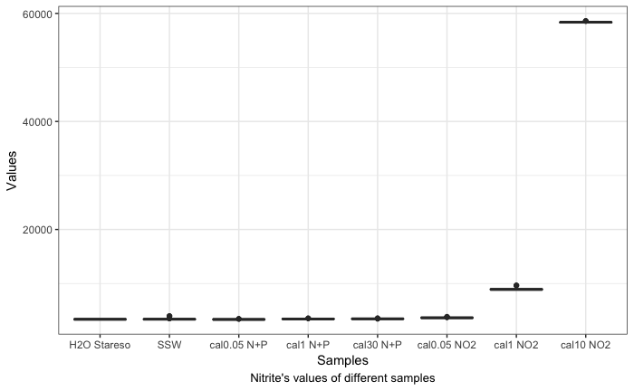

```r
ggplot(data = samp_b, mapping = aes(x = echant,y = NO2_val))+
  geom_boxplot()+
  geom_boxplot() +
  labs( x = "Samples", y = "Values", caption = "Nitrite's values of different samples")+
  theme_bw() +
  theme(plot.caption = element_text(hjust = 0.5))
```

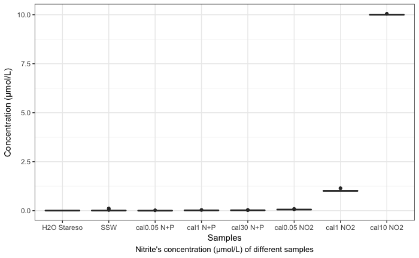

```r
ggplot(data = samp_b, mapping = aes(x = echant,y = NO2_conc))+
  geom_boxplot() +
  labs( x = "Samples", y = "Concentration (µmol/L)", caption = "Nitrite's concentration (µmol/L) of different samples")+
  theme_bw() +
  theme(plot.caption = element_text(hjust = 0.5))
```

```r
samp_b %>%
  group_by(echant)%>%
  summarise(mean = round(mean(NO2_conc), digits = 4),
            sd = round(sd(NO2_conc), digits = 4),cv = round(x = ((sd/mean)*100), digits = 4) ,
            number = length(NO2_conc)) -> a
kable(a, format = "pandoc", caption = "Mean, standard deviation (sd) and variation coefficient (cv) of Nitrite's concentrations of different samples.")
```

Mean, standard deviation (sd) and variation coefficient (cv) of Nitrite's concentrations of different samples.

| echant | mean | sd | cv | number |
| --- | --- | --- | --- | --- |
| H2O Stareso | 0.0072 | 0.0076 | 105.5556 | 10 |
| SSW | 0.0198 | 0.0340 | 171.7172 | 10 |
| cal0.05 N+P | 0.0042 | 0.0068 | 161.9048 | 10 |
| cal1 N+P | 0.0183 | 0.0095 | 51.9126 | 10 |
| cal30 N+P | 0.0226 | 0.0061 | 26.9912 | 10 |
| cal0.05 NO2 | 0.0601 | 0.0121 | 20.1331 | 10 |
| cal1 NO2 | 1.0250 | 0.0431 | 4.2049 | 10 |
| cal10 NO2 | 10.0056 | 0.0192 | 0.1919 | 10 |

# Discussion & perspective

The SSW (water that uses to prepare calibration line and blank) must be purified.

The sea water is obtained by the mixing of Milli-Q, [sodium chloride](https://uk.vwr.com/store/product/777308/vwrc27810) ( $NaCl$, AnalaR Normapur ACS) and [sodium hydrogen carbonate](https://uk.vwr.com/store/product/776026/vwrc27778) ($NaHCO_{3}$, AnalaR Normapur ACS). $35g/L$ of $NaCl$ and $0.2 g/L$ of $NaHCO_{3}$ are added to Milli-Q.

The sodium chloride and sodium hydrogen carbonate are not clean. There are a slight contamination. In $NaCl$, you can find 5ppm of phosphate total Nitrogen at most. You can also find 30ppm of a mixing between $ClO_3$ and $NO_3$. The contaminants of $NaHCO_{3}$ are less important.

- For 5ppm of $PO_4$ :

$$5mg \ PO4 \Longrightarrow \ 1kg \ NaCl$$
$$35g \ NaCl + \ 1L \ MilliQ = synthetic \ sea \ water$$
$$175\mu g \Longrightarrow \ 1L\ synthetic \ sea \ water$$
$$\frac{175\mu g/L}{94 \ g/mol} = 1.86 \ \mu mol/L$$
The same equations can be using for total nitrogen. **Attention, the molar mass changes**.

$$\frac{175 \ \mu g/L}{14 \ g/mol} = 12.5 \ \mu mol/L$$

In the SSW, you can find $1.86 \ \mu mol/L$ of $PO_4$ and $12.5 \ \mu mol/L$ of total nitrogen at most. It is impossible to know the importance of contaminants.

IT is important that find a method to age SSW.

The new experiment must be prepared to check the difference between 0 (in calibration line) and 0 in Stareso sea water samples.